# Assignment 1

Paolo Mariani 800307

# Albero di decisione associato al problema

Analizzando il caso proposto relativo alla scelta che deve essere presa da MC Manufacturing si decide di approcciare alla risoluzione del problema applicando un Decision Tree; il risultato può ossere osservato graficamente di seguito:

```r
tree = yaml.load_file(input = "H:\\Università\\Magistrale\\1° Anno\\Secondo Semestre\\Decision Models\\Assignment Paolo Mariani\\assignment_tree.yaml")

result =dtree(yl = tree)

summary(result, input = FALSE, output = TRUE)
```

```
## Variable input values:
##
## costorun            250000
## costosingolaboard        2
## prezzovenditaboard       5
## npramo11            100000
## npramo12             50000
## npramo21            350000
## npramo22           -150000
##
## Initial decision tree:
##                               Probability      Payoff Cost     Type
##  Produzione Board
##   ¦--Produco 100k unita                                    decision
##   ¦   ¦--esercita opzione         50.00 %  100,000.00        chance
##   ¦   °--non esercita opzione     50.00 %   50,000.00        chance
##   °--Produco 200k unita                                    decision
##       ¦--esercita opzione         50.00 %  350,000.00        chance
##       °--non esercita opzione     50.00 % -150,000.00        chance
##
## Final decision tree:
##                               Probability      Payoff Cost     Type
##  Produzione Board                          100,000.00
##   ¦--Produco 100k unita                     75,000.00      decision
##   ¦   ¦--esercita opzione         50.00 %  100,000.00        chance
##   ¦   °--non esercita opzione     50.00 %   50,000.00        chance
##   °--Produco 200k unita                    100,000.00      decision
##       ¦--esercita opzione         50.00 %  350,000.00        chance
##       °--non esercita opzione     50.00 % -150,000.00        chance
```

```r
plot(result, final = FALSE)
```

[interactive chart not shown]

Sono state fatte delle considerazioni legate ai costi che l’azienda MC Manufacturing deve sostenere, in particolare è stato deciso nella fase di progettazione del modello che i costi non dovessero comparire come fissi ma bensì come costi variabili: nonstante l’azienda paghi sempre il costo per produrre 100000 unità in ogni singolo ramo (poichè DISCO Electronics ha effettuato un ordine di 100000 unità per cui va sempre sostenuta una spesa di produzione da 250000$), si considera il costo variabile poichè il numero di volte che una run viene sostenuta (una o due volte) varia in base alla volontà dell’azienda di produrre immediatamente 200000 unità o di voler attendere che DISCO Electronics eserciti o meno l’opzione.

# Albero di decisione aggiornato con valori attesi di profitto

A partire dall’albero ottenuto al punto precedente, è possibile stabilire come criterio decisionale quello del Valore Atteso (EV); si può calcolare per ogni singolo ramo il valore atteso associato e considerare quello con l’EV più alto come migliore alternativa in funzione delle informazioni che si possiedono:

```r
plot(result, final = TRUE)
```

[interactive chart not shown]

Considerando valido il criterio dell’Expected Value si può osservare che l’azienda trarrebbe vantaggio a produrre 200000 unità immediatamente in un’unica run: al 50% di probabilità DISCO Electronics sceglierebbe di esercitare l’opzione, non sarebbe necessario eseguire nuovamente una seconda run di produzione che comporterebbe costi aggiunti di 250000$; nonostante questo ramo rappresenti il migliore in funzione del valore atteso, è importante sottolineare che non è il ramo associato ad un rischio inferiore (proprio questo ramo è l’unico che possiede al 50% di probabilità una perdita di 150000$ nel caso in cui DISCO Electronics non dovesse eseritare l’opzione nonostante i prodotti risulterebbero già pronti per la consegna).

# Funzione di Utilità e Certainty Equivalent

Si suppone ora di conoscere la tolleranza al rischio di MC Manufacturing, pari a 100000$.  
È possibile quindi calcolare l’**Utilità Attesa**, l’**Equivalente Certo** ed anche il ramo ottimale per l’azienda.

## Utilità Attesa

Si determina l’Utilità Attesa dei rami attraverso la funzione di utilità esponenziale $U(x)=1-e^{(-x/R)}$:

```r
utilityFunctionExp = function(X, R) {
  u = 1- exp(-X/R)
  return(u)
}
```

Questa funzione possiede il seguente andamento, al variare di x, considerando la tolleranza al rischio R = 100000$:

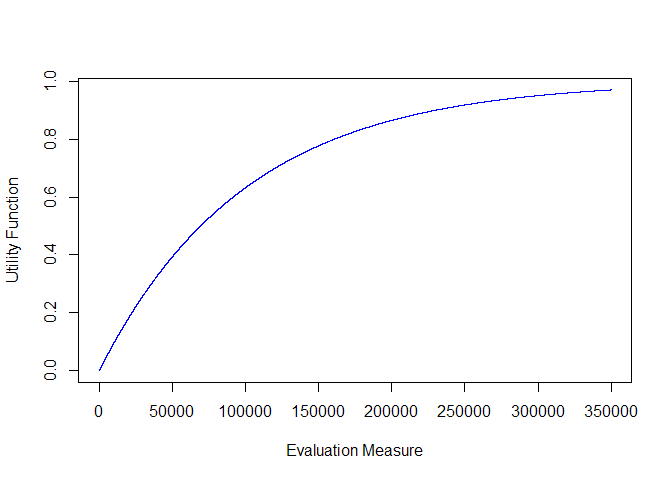

```r
x = seq(from = 0, to = 350000, by = 10)
plot(x, utilityFunctionExp(x, 100000), type="l", col="blue", ylab="Utility Function", xlab="Evaluation Measure")
```

## Certain Equivalent

Per calcolare il Certain Equivalent di un ramo si procede considerando il risultato della funzione di utilità associato al ramo e, tenendo conto della tolleranza al rischio R, si applica la formula $CE = -R*ln(1-EU)$; È stata implementata con il seguente codice R:

```r
CEquivalent = function(EU, R){
  CE = -R*ln(1-EU)
  return(CE)
}
```

## Applicazione delle funzioni ai risultati

Per poter effettuare il calcolo dei valori della Exponential Utility Function e del relativo Certain Equivalent, si decide di sfruttare un semplice vettore composto da tutti i Net Profit ottenuti nel decision tree in quanto la complessità dell’albero è molto ridotta.  
L’applicazione delle funzioni per calcolare il valore delle misure viene implementata attraverso il codice R presentato di seguito.

```r
NP = c(100000, 50000, 350000, -150000)
```

Si calcola, dato il valore di ogni endpoint, l’utilità associata:

```r
#considero R=100000
vett = c()
R = 100000
for(x in c(1:4)){
  vett[x]= utilityFunctionExp(NP[x], R)
}
```

I risultati che vengono restituiti dall’applicazione della funzione sono i seguenti:

```r
df1= data.frame("Ramo"= c("ramo 1","ramo 2","ramo 3", "ramo 4"), "Valore" = vett)
kable(df1)
```

| Ramo | Valore |
| --- | --- |
| ramo 1 | 0.6321206 |
| ramo 2 | 0.3934693 |
| ramo 3 | 0.9698026 |
| ramo 4 | -3.4816891 |

Dati i valori della funzione di utilità degli endpoint è possibile calcolare quello associato ai chance node situati alla loro sinistra:

```r
branch1 = vett[1]*0.5 + vett[2]*0.5
branch2 = vett[3]*0.5 + vett[4]*0.5

df2= data.frame("Ramo" = c("branch 1", "branch 2"), "Valore" = (c(branch1, branch2)))
#kable(t(c(branch1, branch2)))
kable(df2)
```

| Ramo | Valore |
| --- | --- |
| branch 1 | 0.5127949 |
| branch 2 | -1.2559432 |

Si calcolano quindi i Certain Equivalent per ogni chance node e successivamente si seleziona, tra i valori ottenuti, il ramo con il valore associato più alto: si tratta di quello relativo alla scelta che converrebbe seguire all’azienda una volta considerata la propensione al rischio:

```r
CE1 = CEquivalent(branch1, R)
CE2 = CEquivalent(branch2, R)
df3= data.frame("Ramo" = c("branch 1", "branch 2"), "Valore" = c(CE1, CE2))
kable(df3)
```

| Ramo | Valore |
| --- | --- |
| branch 1 | 71907.02 |
| branch 2 | -81356.82 |

# Cambio del processo di produzione

MC Manufacturing ha la possibilità di sviluppare un nuovo sistema di produzione che permette di risparmiare 200000$ per ogni run che verrà svolta successivamente alla prima, riducendo la cifra per ognuna a 50000$; i costi di R&D per cambiare il processo di produzione possono essere sostenuti per 25000$ (ritenuti anche in questo caso variabili e non fissi in quanto dipendono dalla volontà dell’azienda di effettuare l’investimento), la scelta di effettuare l’investimento verrebbe effettuata dopo aver prodotto già 100000 unità, ma comunque prima di ricevere una risposta da DISCO Electronics sull’opzione. Nell’albero decisionale di conseguenza verrà introdotto un nuovo decision node che separa la scelta di voler investire o meno nel nuovo processo produttivo, modificando esclusivamente la porzione legata alla produzione di 100000 unità e non modificando in alcun modo la produzione immediata di 200000 unità.  
Di conseguenza, in funzione dell’esito dell’eventuale fase di R&D, si potrà godere di un costo per run ridotto (se efficace) o mantenere lo stesso costo (perdendo 25000$ in caso di R&D inefficace).  
L’albero di decisione associato alla modifica del processo produttivo è il seguente:

```r
tree = yaml.load_file(input = "H:\\Università\\Magistrale\\1° Anno\\Secondo Semestre\\Decision Models\\Assignment Paolo Mariani\\assignment_tree4.yaml")

result =dtree(yl = tree)

summary(result, input = FALSE, output = TRUE)
```

```
## Variable input values:
##
## costorun                250000
## costord                  25000
## costonuovarun            50000
## costosingolaboard            2
## prezzovenditaboard           5
## nordopzione             100000
## nordnoopzione            50000
## npramo21                350000
## npramo22               -150000
## ricsuccessoopzione      275000
## ricsuccessonoopzione     25000
## ricinsuccessoopzione     75000
## ricinsuccessonoopzione   25000
##
## Initial decision tree:
##                                               Probability      Payoff Cost
##  Produzione Board
##   ¦--Produco 100k unita e attendo
##   ¦   ¦--Ricerca e Sviluppo
##   ¦   ¦   ¦--processo produttivo efficace         40.00 %
##   ¦   ¦   ¦   ¦--esercita opzione                 50.00 %  275,000.00
##   ¦   ¦   ¦   °--non esercita opzione             50.00 %   25,000.00
##   ¦   ¦   °--processo produttivo non efficace     60.00 %
##   ¦   ¦       ¦--esercita opzione                 50.00 %   75,000.00
##   ¦   ¦       °--non esercita opzione             50.00 %   25,000.00
##   ¦   °--No Ricerca e Sviluppo
##   ¦       ¦--esercita opzione                     50.00 %  100,000.00
##   ¦       °--non esercita opzione                 50.00 %   50,000.00
##   °--Produco 200k unita
##       ¦--esercita opzione                         50.00 %  350,000.00
##       °--non esercita opzione                     50.00 % -150,000.00
##      Type
##
##  decision
##  decision
##    chance
##    chance
##    chance
```

[output cut: 28 more lines]

```
##
##  decision
##  decision
##    chance
##    chance
##    chance
##    chance
##    chance
##    chance
##  decision
##    chance
##    chance
##  decision
##    chance
##    chance
```

```r
plot(result, final = TRUE)
```

[interactive chart not shown]

Dal risultato ottenuto per mezzo del valore atteso, comprendiamo come sia vantaggioso produrre 200000 schede immediatamente.

# Valore dell’informazione perfetta

Supponendo che l’azienda MC Manufacturing possa confrontarsi con un esperto per ottenere informazioni relative all’esito dell’attività di R&D, si può determinare quanto valga l’informazione perfetta e quanto l’azienda sia disposta a pagare al massimo per essa.  
L’albero che viene rappresentato di seguito riassume la decisione dell’azienda di consultare l’esperto ed investire in R&D o no, con i seguenti rami che ne indicano le conseguenze della decisione:

```r
tree = yaml.load_file(input = "H:\\Università\\Magistrale\\1° Anno\\Secondo Semestre\\Decision Models\\Assignment Paolo Mariani\\assignment_tree3.yaml")

result =dtree(yl = tree)

summary(result, input = FALSE, output = TRUE)
```

```
## Variable input values:
##
## costorun                    250000
## costord                      25000
## costonuovarun                50000
## costosingolaboard                2
## prezzovenditaboard               5
## npramo111                   300000
## npramo112                    50000
## npramo121                   100000
## npramo122                    50000
## npramo21                    350000
## npramo22                   -150000
## npramo1efficaceopzione      275000
## npramo1efficacenoopzione     25000
## npramo1noefficaceopzione     75000
## npramo1noefficacenoopzione   50000
##
## Initial decision tree:
##                                           Probability      Payoff Cost
##  Produzione Board
##   °--Faccio la R&D?
##       ¦--Faccio Ricerca e Sviluppo            40.00 %
##       ¦   ¦--viene esercitata opzione         50.00 %  275,000.00
##       ¦   °--non viene esercitata opzione     50.00 %   25,000.00
##       °--Non Faccio Ricerca e Sviluppo        60.00 %
##           ¦--viene esercitata opzione         50.00 %  350,000.00
##           °--non viene esercitata opzione     50.00 % -150,000.00
##      Type
##
##  decision
##    chance
##    chance
##    chance
##    chance
##    chance
##    chance
##
## Final decision tree:
##                                           Probability      Payoff Cost
##  Produzione Board                                      120,000.00
##   °--Faccio la R&D?                                    120,000.00
##       ¦--Faccio Ricerca e Sviluppo            40.00 %  150,000.00
##       ¦   ¦--viene esercitata opzione         50.00 %  275,000.00
##       ¦   °--non viene esercitata opzione     50.00 %   25,000.00
##       °--Non Faccio Ricerca e Sviluppo        60.00 %  100,000.00
##           ¦--viene esercitata opzione         50.00 %  350,000.00
##           °--non viene esercitata opzione     50.00 % -150,000.00
##      Type
##
##  decision
##    chance
##    chance
##    chance
##    chance
##    chance
##    chance
```

```r
plot(result, final = TRUE)
```

[interactive chart not shown]

Come è possibile osservare dall’albero l’azienda MC Manufacturing, per ottenere l’informazione perfetta sull’esito dell’investimento, può pagare fino ad un massimo di 120000-100000= 20000$: i 120000$ sono quelli ottenuti come valore atteso nel caso in cui MC Manufacturing investisse i 25000$ per cambiare il processo produttivo su consiglio dell’esperto, i 100000$ sono associati al profitto atteso che si otterrebbe nel caso in cui si producessero 200000 unità immediatamente senza investire il denaro ai fini della ricerca (rappresenta l’alternativa che dal punto di vista del valore atteso è la più proficua per l’azienda).